# CBC

5/24/2019

The objective of conjoint analysis is to measure how respondents trade-off various alternatives and their respective attribute levels; for example, the trade-off a consumer faces is whether to buy a cheaper car with higher fuel consumption or a more expensive one with lower fuel consumption. Conjoint analysis is a survey technique that asks respondents to evaluate products. These product evaluations are then decomposed to derive estimates on the utilities of the products constituent attribute levels (the part-worths). Conjoint analysis is thus a decompositional approach.

Researchers can estimate part-worths based on estimation techniques such as regression analysis (ratings-based data) or multinomial logistic regression (choice data). The total value of an alternative can then be computed as the sum of its respective part-worth utilities. Almost all published research on conjoint analysis and preference measurement is based on the assumption of a linear additive utility model.

http://www.rpubs.com/angelayy/185881

http://r-marketing.r-forge.r-project.org/Instructor/Chapter13/Chapter13-ChapmanFeit.html#/

Data summary: there are 200 respondents conducted the survey. Each survey includes 15 questions, each question has 3 options or 3 althernatives. There are 5 product features or attributes.

```r
knitr::opts_chunk$set(echo = TRUE)

library(tidyverse)
library(readr)
library(rstan)
```

Data preparation / Preparción de los datos

```r
cbc_df <- read_csv("http://goo.gl/5xQObB", col_types = "iiiccccci")
glimpse(cbc_df)
```

```
## Observations: 9,000
## Variables: 9
## $ resp.id <int> 1, 1, 1, 1, 1, 1, 1, 1, 1, 1, 1, 1, 1, 1, 1, 1, 1, 1, 1,…
## $ ques    <int> 1, 1, 1, 2, 2, 2, 3, 3, 3, 4, 4, 4, 5, 5, 5, 6, 6, 6, 7,…
## $ alt     <int> 1, 2, 3, 1, 2, 3, 1, 2, 3, 1, 2, 3, 1, 2, 3, 1, 2, 3, 1,…
## $ carpool <chr> "yes", "yes", "yes", "yes", "yes", "yes", "yes", "yes", …
## $ seat    <chr> "6", "8", "6", "6", "7", "6", "8", "7", "8", "7", "8", "…
## $ cargo   <chr> "2ft", "3ft", "3ft", "2ft", "3ft", "2ft", "3ft", "3ft", …
## $ eng     <chr> "gas", "hyb", "gas", "gas", "gas", "elec", "gas", "elec"…
## $ price   <chr> "35", "30", "30", "30", "35", "35", "35", "30", "40", "4…
## $ choice  <int> 0, 0, 1, 0, 1, 0, 1, 0, 0, 1, 0, 0, 1, 0, 0, 0, 1, 0, 1,…
```

```r
cbc_df <- cbc_df %>%
    mutate_if(is.character, list(int = ~as.integer(as.factor(.)))) %>%
    rename(resp_id = resp.id)

cbc_levels <- cbc_df %>%
    select(carpool:price) %>%
    map_df(~data_frame(label = levels(factor(.)),
        level = 1:n_distinct(label)), .id = "var")
# using sawtooth's defult format where the choice values repeats along a task
cbc_saw <- cbc_df %>%
    group_by(resp_id, ques) %>%
    mutate(choice = choice %*% alt) %>%
    ungroup() %>%
    select(resp_id:alt, choice, carpool_int:price_int)
glimpse(cbc_saw)
```

```
## Observations: 9,000
## Variables: 9
## $ resp_id     <int> 1, 1, 1, 1, 1, 1, 1, 1, 1, 1, 1, 1, 1, 1, 1, 1, 1, 1…
## $ ques        <int> 1, 1, 1, 2, 2, 2, 3, 3, 3, 4, 4, 4, 5, 5, 5, 6, 6, 6…
## $ alt         <int> 1, 2, 3, 1, 2, 3, 1, 2, 3, 1, 2, 3, 1, 2, 3, 1, 2, 3…
## $ choice      <dbl> 3, 3, 3, 2, 2, 2, 1, 1, 1, 1, 1, 1, 1, 1, 1, 2, 2, 2…
## $ carpool_int <int> 2, 2, 2, 2, 2, 2, 2, 2, 2, 2, 2, 2, 2, 2, 2, 2, 2, 2…
## $ seat_int    <int> 1, 3, 1, 1, 2, 1, 3, 2, 3, 2, 3, 1, 1, 1, 1, 1, 2, 2…
## $ cargo_int   <int> 1, 2, 2, 1, 2, 1, 2, 2, 1, 2, 2, 1, 2, 2, 2, 1, 1, 1…
## $ eng_int     <int> 2, 3, 2, 2, 2, 1, 2, 1, 1, 1, 2, 3, 1, 1, 3, 1, 2, 3…
## $ price_int   <int> 2, 1, 1, 1, 2, 2, 2, 1, 3, 3, 3, 1, 1, 3, 3, 3, 2, 2…
```

```r
# Stan model recieves number of options in each variable (as list)
n_vars <- cbc_saw %>%
    summarise_if(is.numeric, max) %>%
    select(-choice) %>%
    map(~.)
names_vars_n <- str_c("n_", str_remove(names(n_vars), "_int"))
n_vars <- set_names(n_vars, names_vars_n)

# index matrix for iterations
index <- array(0, dim = c(n_vars$n_resp_id, n_vars$n_ques, n_vars$n_alt))

r <- 1
for(i in 1:n_vars$n_resp_id){
    for(j in 1:n_vars$n_ques){
        for(k in 1:n_vars$n_alt){
            index[i, j, k] <- r
            r <- r + 1
        }
    }
}

vars <- map(cbc_saw, ~.)
params_stan <- c(N = nrow(cbc_saw), n_vars, vars, list(index = index))
```

## Modelo 1

Modelo

The parameter estimates are on the logit scale and typically range between -2 to 2. With higher value, suggest strongly like (positive) or dislike (negative)

```r
fit_1 <- stan(file = "../stan_files/logistic-multinomial.stan",
  data = params_stan, iter = 500, chains = 2, cores = 3, thin = 5,
  verbose = FALSE, seed = 457,
    pars = c("b_cargo_c", "b_seat_c", "b_eng_c", "b_price_c"))

write_rds(fit_1, path = "../data_output/model_fits/model_1.rds")
```

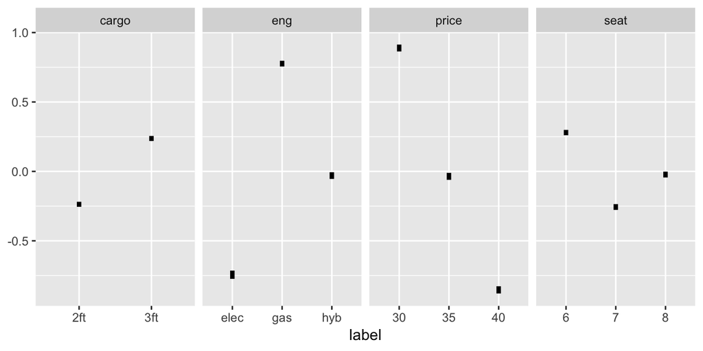

```r
fit_1 <- read_rds(path = "../data_output/model_fits/model_1.rds")

get_summary_coef <- function(fit, data_levels = cbc_levels){
    summary_fit <- summary(fit)$summary %>%
        as_tibble(rownames = "coef") %>%
        mutate(
            var = str_extract(coef, pattern = "_([a-z]+)_|_([a-z]+)") %>%
                str_remove_all("_"),
            level = str_extract(coef, pattern = "[0-9]+(])$") %>%
                str_remove_all("]") %>% as.integer(),
            ind = str_extract(coef, pattern = "[0-9]+(,)") %>%
                str_remove_all(",") %>% as.integer()
            ) %>%
        filter(!is.na(var), !is.na(level)) %>%
        left_join(cbc_levels, by = c("var", "level"))
}

summary_fit_plot <- get_summary_coef(fit_1, cbc_levels)

ggplot(summary_fit_plot, aes(x = label, ymin = `25%`, ymax = `75%`)) +
    geom_linerange(size = 1.5) +
    facet_wrap(~var, scales = "free_x", nrow = 1)
```

### Adding consumer heterogenity

```r
fit_2 <- stan(file = "../stan_files/logistic-multinomial-hetero.stan",
  data = params_stan, iter = 500, chains = 2, cores = 3, thin = 5,
  verbose = FALSE, seed = 457,
    pars = c("mu_cargo_c", "mu_seat_c", "mu_eng_c", "mu_price_c",
        "b_cargo", "b_seat", "b_eng", "b_price"))

write_rds(fit_2, path = "../data_output/model_fits/model_2.rds")
```

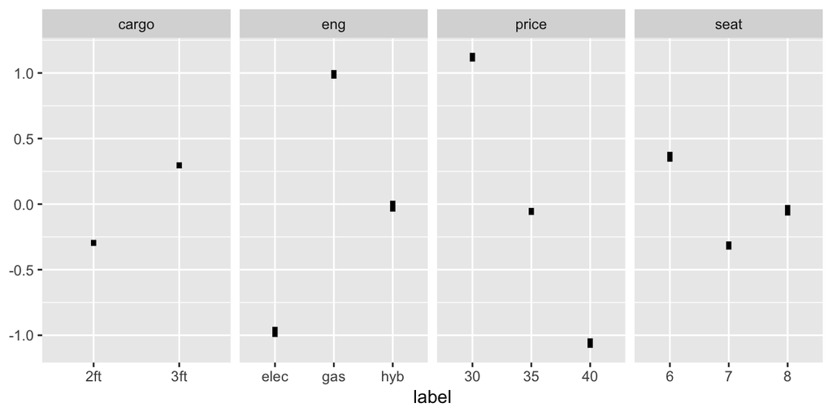

```r
fit_2 <- read_rds(path = "../data_output/model_fits/model_2.rds")

summary_fit_plot <- get_summary_coef(fit_2, cbc_levels)

summary_mus <- filter(summary_fit_plot, str_detect(coef, "mu"))
ggplot(summary_mus, aes(x = label, ymin = `25%`, ymax = `75%`)) +
    geom_linerange(size = 1.5) +
    facet_wrap(~var, scales = "free_x", nrow = 1)
```

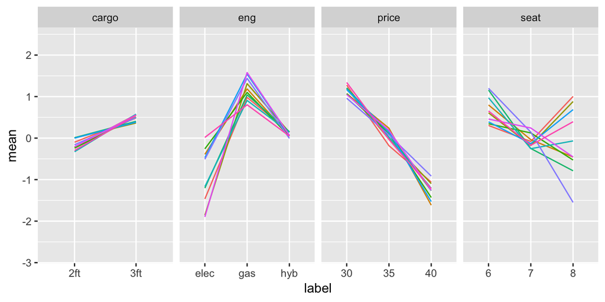

```r
summary_inds <- filter(summary_fit_plot, !str_detect(coef, "mu"))
ids_sample <- sample(1:200, 10)

ggplot(filter(summary_inds, ind %in% ids_sample) ,
    aes(x = label, y = mean, ymin = `25%`, ymax = `75%`)) +
    geom_path(aes(color = factor(ind), group = ind), show.legend = FALSE) +
    facet_wrap(~var, scales = "free_x", nrow = 1)
```